# Do females and males differ in organs scaling? A comparative analysis across vertebrates

## Stomach

### Filter data and prune tree

```r
# Filter organ of interest
dat_organ <- dat_mean %>%
  group_by(organ_grouped, sex) %>%
  ungroup() %>%
  filter(organ_grouped == "stomach")

# Check for database/tree species mismatches
setdiff(tree$tip.label, dat_organ$phylo)      # Tree species absent in database
```

```
  [1] "Petrochromis_famula"             "Lobochilotes_labiatus"
  [3] "Simochromis_diagramma"           "Petrochromis_orthognathus"
  [5] "Ctenochromis_horei"              "Limnotilapia_dardennii"
  [7] "Gnathochromis_pfefferi"          "Tropheus_moorii"
  [9] "Tropheus_brichardi"              "Haplotaxodon_microlepis"
 [11] "Perissodus_microlepis"           "Benthochromis_tricoti"
 [13] "Cyprichromis_leptosoma"          "Greenwoodochromis_christyi"
 [15] "Limnochromis_staneri"            "Gnathochromis_permaxillaris"
 [17] "Baileychromis_centropomoides"    "Triglachromis_otostigma"
 [19] "Cyphotilapia_frontosa"           "Ophthalmotilapia_ventralis"
 [21] "Cyathopharynx_furcifer"          "Ophthalmotilapia_nasuta"
 [23] "Ophthalmotilapia_boops"          "Aulonocranus_dewindti"
 [25] "Ectodus_descampsii"              "Callochromis_melanostigma"
 [27] "Xenotilapia_melanogenys"         "Xenotilapia_flavipinnis"
 [29] "Eretmodus_cyanostictus"          "Tanganicodus_irsacae"
```

[output cut: 83 more lines]

```r
setdiff(dat_organ$phylo, tree$tip.label)      # Database species absent in tree
```

```
character(0)
```

```r
# Exclude mismatched species for consistency
tree_organ <- keep.tip(tree, intersect(tree$tip.label, dat_organ$phylo))
dat_organ <- dat_organ[dat_organ$phylo %in% tree_organ$tip.label, ]

# Re-check for mismatches after pruning
setdiff(tree_organ$tip.label, dat_organ$phylo)
```

```
character(0)
```

```r
setdiff(dat_organ$phylo, tree_organ$tip.label)
```

```
character(0)
```

```r
# Is ultrametric?
is.ultrametric(tree_organ)
```

```
[1] TRUE
```

```r
# how many species?
length(tree_organ$tip.label)
```

```
[1] 8
```

```r
# Compute phylogenetic covariance matrix
A_organ <- ape::vcv.phylo(tree_organ, corr = TRUE)
```

### Model simple

```r
model_simple_stomach <- brm(
  log10_organ_size ~
    1 +
    log10_body_size +
    (1 + log10_body_size | sex),
  data = dat_organ,
  family = gaussian(),
    prior = c(
    prior(normal(0.75, 0.5), class = "b", coef = "log10_body_size"),
    prior(normal(0, 2), class = "Intercept"),
    prior(student_t(3, 0, 0.5), class = "sd"),
    prior(student_t(3, 0, 1),   class = "sigma")
  ),
  seed = 6955,
  sample_prior = TRUE,
  chains = 4,
  cores = 4,
  threads = threading(2),
  iter = 4000,
  warmup = 2000,
  control = list(max_treedepth = 15,
                 adapt_delta = 0.99),
  save_pars = save_pars(all = TRUE),
  silent = TRUE, refresh = 0
)
```

```
Running MCMC with 4 parallel chains, with 2 thread(s) per chain...

Chain 1 finished in 2.4 seconds.
Chain 3 finished in 2.4 seconds.
Chain 2 finished in 2.6 seconds.
Chain 4 finished in 2.6 seconds.

All 4 chains finished successfully.
Mean chain execution time: 2.5 seconds.
Total execution time: 2.7 seconds.
```

**Model check**

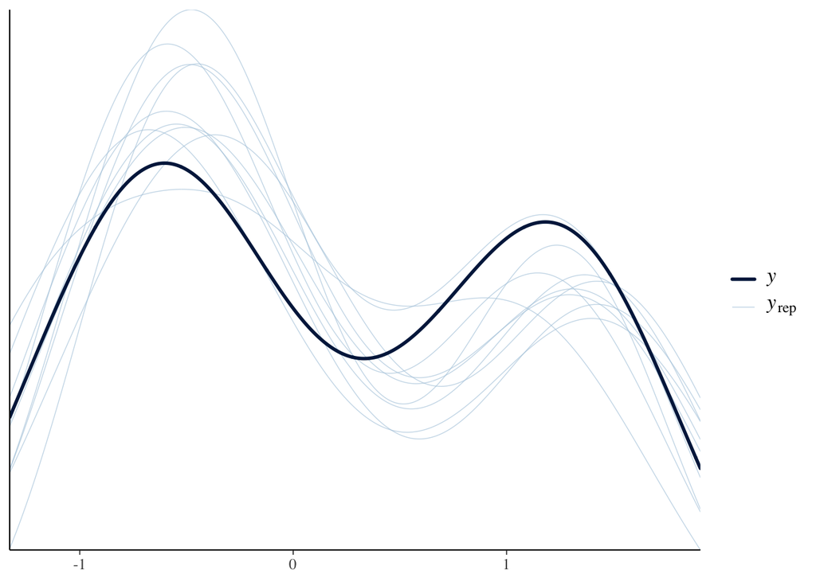

```r
pp_check(model_simple_stomach)
```

**Model summary**

```r
summary(model_simple_stomach)
```

```
 Family: gaussian
  Links: mu = identity
Formula: log10_organ_size ~ 1 + log10_body_size + (1 + log10_body_size | sex)
   Data: dat_organ (Number of observations: 16)
  Draws: 4 chains, each with iter = 4000; warmup = 2000; thin = 1;
         total post-warmup draws = 8000

Multilevel Hyperparameters:
~sex (Number of levels: 2)
                               Estimate Est.Error l-95% CI u-95% CI Rhat
sd(Intercept)                      0.29      0.30     0.01     1.08 1.00
sd(log10_body_size)                0.20      0.23     0.00     0.84 1.00
cor(Intercept,log10_body_size)    -0.09      0.60    -0.98     0.95 1.00
                               Bulk_ESS Tail_ESS
sd(Intercept)                      3636     3639
sd(log10_body_size)                1837     3384
cor(Intercept,log10_body_size)     3837     4182

Regression Coefficients:
                Estimate Est.Error l-95% CI u-95% CI Rhat Bulk_ESS Tail_ESS
Intercept          -2.63      0.33    -3.28    -1.95 1.00     4295     3726
log10_body_size     1.18      0.18     0.71     1.48 1.00     2080     1216

Further Distributional Parameters:
      Estimate Est.Error l-95% CI u-95% CI Rhat Bulk_ESS Tail_ESS
sigma     0.23      0.05     0.15     0.35 1.00     5037     3724

Draws were sampled using sample(hmc). For each parameter, Bulk_ESS
and Tail_ESS are effective sample size measures, and Rhat is the potential
scale reduction factor on split chains (at convergence, Rhat = 1).
```

**Coeficients by sex**

```r
# Extract combined coefficients (fixed + random)
coef(model_simple_stomach)$sex %>%
{tibble(
  sex = dimnames(.)[[1]],
  intercept    = .[, "Estimate", "Intercept"],
  intercept_low  = .[, "Q2.5", "Intercept"],
  intercept_high = .[, "Q97.5", "Intercept"]
)} %>%
bind_cols(
  tibble(
    sex = dimnames(coef(model_simple_stomach)$sex)[[1]],
    slope = coef(model_simple_stomach)$sex[, "Estimate", "log10_body_size"]
  ) %>% select(slope),
  tibble(
    sex = dimnames(coef(model_simple_stomach)$sex)[[1]],
    slope_low  = coef(model_simple_stomach)$sex[, "Q2.5", "log10_body_size"],
    slope_high = coef(model_simple_stomach)$sex[, "Q97.5", "log10_body_size"]
  ) %>% select(slope_low, slope_high)
)
```

```
# A tibble: 2 × 7
  sex    intercept intercept_low intercept_high slope slope_low slope_high
  <chr>      <dbl>         <dbl>          <dbl> <dbl>     <dbl>      <dbl>
1 female     -2.63         -3.03          -2.22  1.23      1.05       1.39
2 male       -2.64         -3.04          -2.23  1.23      1.06       1.39
```

### Model with phylogeny

```r
model_phylo_stomach <- brm(
  log10_organ_size ~
    1 +
    log10_body_size +
    (1 + log10_body_size | sex) +
    (1 | gr(phylo, cov = A_organ)),
  data = dat_organ,
  data2 = list(A_organ = A_organ),
  family = gaussian(),
    prior = c(
    prior(normal(0.75, 0.5), class = "b", coef = "log10_body_size"),
    prior(normal(0, 2), class = "Intercept"),
    prior(student_t(3, 0, 0.5), class = "sd"),
    prior(student_t(3, 0, 1),   class = "sigma")
  ),
  seed = 6955,
  sample_prior = TRUE,
  chains = 4,
  cores = 4,
  threads = threading(2),
  iter = 4000,
  warmup = 2000,
  control = list(max_treedepth = 15,
                 adapt_delta = 0.99),
  save_pars = save_pars(all = TRUE),
  silent = TRUE, refresh = 0
)
```

```
Running MCMC with 4 parallel chains, with 2 thread(s) per chain...

Chain 2 finished in 14.4 seconds.
Chain 1 finished in 16.9 seconds.
Chain 4 finished in 17.2 seconds.
Chain 3 finished in 22.0 seconds.

All 4 chains finished successfully.
Mean chain execution time: 17.6 seconds.
Total execution time: 22.1 seconds.
```

**Model check**

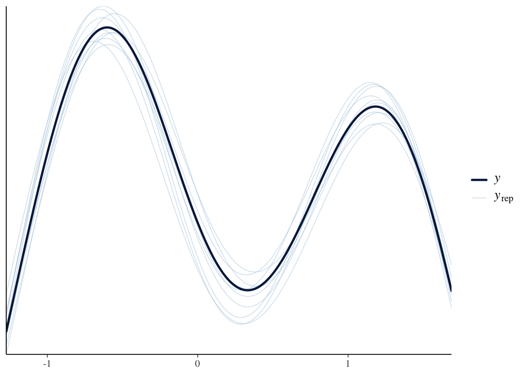

```r
pp_check(model_phylo_stomach)
```

**Model summary**

```r
summary(model_phylo_stomach)
```

```
 Family: gaussian
  Links: mu = identity
Formula: log10_organ_size ~ 1 + log10_body_size + (1 + log10_body_size | sex) + (1 | gr(phylo, cov = A_organ))
   Data: dat_organ (Number of observations: 16)
  Draws: 4 chains, each with iter = 4000; warmup = 2000; thin = 1;
         total post-warmup draws = 8000

Multilevel Hyperparameters:
~phylo (Number of levels: 8)
              Estimate Est.Error l-95% CI u-95% CI Rhat Bulk_ESS Tail_ESS
sd(Intercept)     0.39      0.13     0.22     0.70 1.00     2453     4006

~sex (Number of levels: 2)
                               Estimate Est.Error l-95% CI u-95% CI Rhat
sd(Intercept)                      0.21      0.27     0.00     0.93 1.00
sd(log10_body_size)                0.13      0.18     0.00     0.63 1.00
cor(Intercept,log10_body_size)    -0.05      0.62    -0.98     0.96 1.00
                               Bulk_ESS Tail_ESS
sd(Intercept)                      3348     3977
sd(log10_body_size)                2424     3143
cor(Intercept,log10_body_size)     5595     5115

Regression Coefficients:
                Estimate Est.Error l-95% CI u-95% CI Rhat Bulk_ESS Tail_ESS
Intercept          -1.96      0.42    -2.74    -1.09 1.00     3111     3808
log10_body_size     0.87      0.17     0.52     1.20 1.00     2549     3676

Further Distributional Parameters:
      Estimate Est.Error l-95% CI u-95% CI Rhat Bulk_ESS Tail_ESS
sigma     0.04      0.02     0.02     0.08 1.00     2226     3234

Draws were sampled using sample(hmc). For each parameter, Bulk_ESS
and Tail_ESS are effective sample size measures, and Rhat is the potential
scale reduction factor on split chains (at convergence, Rhat = 1).
```

**Phylogenetic signal**

```r
hyp <- paste(
  "sd_phylo__Intercept^2 /",
  "(sd_phylo__Intercept^2 + sd_sex__Intercept^2 + sigma^2) = 0"
)
(hyp <- hypothesis(model_phylo_stomach, hyp, class = NULL))
```

```
Hypothesis Tests for class :
                Hypothesis Estimate Est.Error CI.Lower CI.Upper Evid.Ratio
1 (sd_phylo__Interc... = 0     0.77      0.26     0.12     0.99       0.02
  Post.Prob Star
1      0.02    *
---
'CI': 90%-CI for one-sided and 95%-CI for two-sided hypotheses.
'*': For one-sided hypotheses, the posterior probability exceeds 95%;
for two-sided hypotheses, the value tested against lies outside the 95%-CI.
Posterior probabilities of point hypotheses assume equal prior probabilities.
```

```r
lambda_stomach <- hyp$hypothesis$Estimate
```

**Coeficients by sex**

```r
# Extract combined coefficients (fixed + random)
coef(model_phylo_stomach)$sex %>%
{tibble(
  sex = dimnames(.)[[1]],
  intercept    = .[, "Estimate", "Intercept"],
  intercept_low  = .[, "Q2.5", "Intercept"],
  intercept_high = .[, "Q97.5", "Intercept"]
)} %>%
bind_cols(
  tibble(
    sex = dimnames(coef(model_phylo_stomach)$sex)[[1]],
    slope = coef(model_phylo_stomach)$sex[, "Estimate", "log10_body_size"]
  ) %>% select(slope),
  tibble(
    sex = dimnames(coef(model_phylo_stomach)$sex)[[1]],
    slope_low  = coef(model_phylo_stomach)$sex[, "Q2.5", "log10_body_size"],
    slope_high = coef(model_phylo_stomach)$sex[, "Q97.5", "log10_body_size"]
  ) %>% select(slope_low, slope_high)
)
```

```
# A tibble: 2 × 7
  sex    intercept intercept_low intercept_high slope slope_low slope_high
  <chr>      <dbl>         <dbl>          <dbl> <dbl>     <dbl>      <dbl>
1 female     -1.94         -2.63          -1.17 0.872     0.586       1.12
2 male       -1.97         -2.65          -1.21 0.878     0.594       1.13
```

### Model comparison

```r
loo_simple <- loo(model_simple_stomach)
loo_phylo <- loo(model_phylo_stomach)
loo_compare(loo_simple, loo_phylo)
```

```
                     elpd_diff se_diff
model_phylo_stomach    0.0       0.0
model_simple_stomach -23.3       3.6
```

In this comparison, the phylogenetic model is clearly preferable to the model treating species as independent observational units. The phylogenetic model (`model_phylo_stomach`) is used as the reference with `elpd_diff = 0`, while the simpler model (`model_simple_stomach`) has an expected log predictive density (ELPD) that is about 23.3 units lower, with an associated standard error of 3.6. In leave-one-out cross-validation, differences exceeding approximately four times their standard error indicate strong evidence. Here, 23.3/3.6≈6.5, providing strong evidence favouring the phylogenetic model..

## Lungs

### Filter data and prune tree

```r
# Filter organ of interest
dat_organ <- dat_mean %>%
  group_by(organ_grouped, sex) %>%
  ungroup() %>%
  filter(organ_grouped == "lungs")

# Check for database/tree species mismatches
setdiff(tree$tip.label, dat_organ$phylo)      # Tree species absent in database
```

```
  [1] "Petrochromis_famula"             "Lobochilotes_labiatus"
  [3] "Simochromis_diagramma"           "Petrochromis_orthognathus"
  [5] "Ctenochromis_horei"              "Limnotilapia_dardennii"
  [7] "Gnathochromis_pfefferi"          "Tropheus_moorii"
  [9] "Tropheus_brichardi"              "Haplotaxodon_microlepis"
 [11] "Perissodus_microlepis"           "Benthochromis_tricoti"
 [13] "Cyprichromis_leptosoma"          "Greenwoodochromis_christyi"
 [15] "Limnochromis_staneri"            "Gnathochromis_permaxillaris"
 [17] "Baileychromis_centropomoides"    "Triglachromis_otostigma"
 [19] "Cyphotilapia_frontosa"           "Ophthalmotilapia_ventralis"
 [21] "Cyathopharynx_furcifer"          "Ophthalmotilapia_nasuta"
 [23] "Ophthalmotilapia_boops"          "Aulonocranus_dewindti"
 [25] "Ectodus_descampsii"              "Callochromis_melanostigma"
 [27] "Xenotilapia_melanogenys"         "Xenotilapia_flavipinnis"
 [29] "Eretmodus_cyanostictus"          "Tanganicodus_irsacae"
```

[output cut: 84 more lines]

```r
setdiff(dat_organ$phylo, tree$tip.label)      # Database species absent in tree
```

```
character(0)
```

```r
# Exclude mismatched species for consistency
tree_organ <- keep.tip(tree, intersect(tree$tip.label, dat_organ$phylo))
dat_organ <- dat_organ[dat_organ$phylo %in% tree_organ$tip.label, ]

# Re-check for mismatches after pruning
setdiff(tree_organ$tip.label, dat_organ$phylo)
```

```
character(0)
```

```r
setdiff(dat_organ$phylo, tree_organ$tip.label)
```

```
character(0)
```

```r
# Is ultrametric?
is.ultrametric(tree_organ)
```

```
[1] TRUE
```

```r
# how many species?
length(tree_organ$tip.label)
```

```
[1] 6
```

```r
# Compute phylogenetic covariance matrix
A_organ <- ape::vcv.phylo(tree_organ, corr = TRUE)
```

### Model simple

```r
model_simple_lungs <- brm(
  log10_organ_size ~
    1 +
    log10_body_size +
    (1 + log10_body_size | sex),
  data = dat_organ,
  family = gaussian(),
    prior = c(
    prior(normal(0.75, 0.5), class = "b", coef = "log10_body_size"),
    prior(normal(0, 2), class = "Intercept"),
    prior(student_t(3, 0, 0.5), class = "sd"),
    prior(student_t(3, 0, 1),   class = "sigma")
  ),
  seed = 6955,
  sample_prior = TRUE,
  chains = 4,
  cores = 4,
  threads = threading(2),
  iter = 4000,
  warmup = 2000,
  control = list(max_treedepth = 15,
                 adapt_delta = 0.99),
  save_pars = save_pars(all = TRUE),
  silent = TRUE, refresh = 0
)
```

```
Running MCMC with 4 parallel chains, with 2 thread(s) per chain...

Chain 4 finished in 1.7 seconds.
Chain 1 finished in 1.9 seconds.
Chain 3 finished in 1.9 seconds.
Chain 2 finished in 2.2 seconds.

All 4 chains finished successfully.
Mean chain execution time: 1.9 seconds.
Total execution time: 2.3 seconds.
```

**Model check**

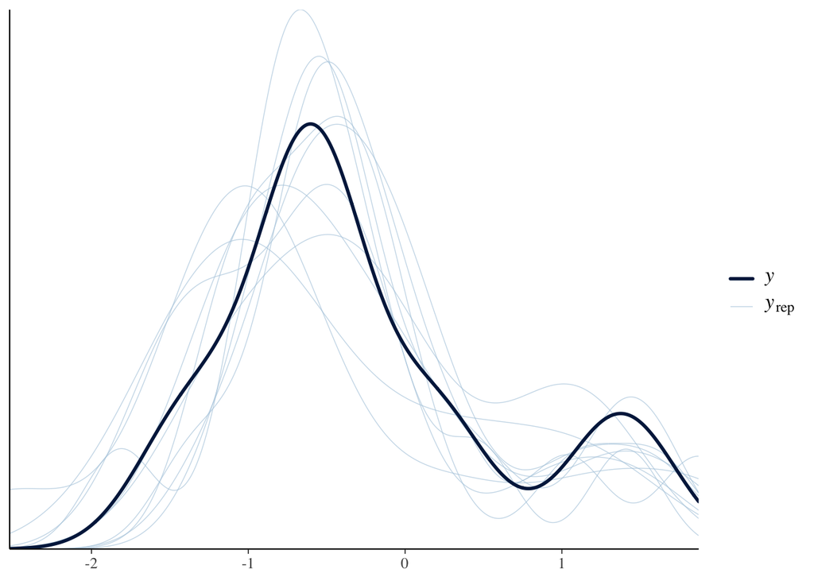

```r
pp_check(model_simple_lungs)
```

**Model summary**

```r
summary(model_simple_lungs)
```

```
 Family: gaussian
  Links: mu = identity
Formula: log10_organ_size ~ 1 + log10_body_size + (1 + log10_body_size | sex)
   Data: dat_organ (Number of observations: 12)
  Draws: 4 chains, each with iter = 4000; warmup = 2000; thin = 1;
         total post-warmup draws = 8000

Multilevel Hyperparameters:
~sex (Number of levels: 2)
                               Estimate Est.Error l-95% CI u-95% CI Rhat
sd(Intercept)                      0.31      0.33     0.01     1.16 1.00
sd(log10_body_size)                0.21      0.23     0.00     0.81 1.00
cor(Intercept,log10_body_size)    -0.08      0.60    -0.97     0.94 1.00
                               Bulk_ESS Tail_ESS
sd(Intercept)                      3402     3559
sd(log10_body_size)                2134     2245
cor(Intercept,log10_body_size)     3557     4522

Regression Coefficients:
                Estimate Est.Error l-95% CI u-95% CI Rhat Bulk_ESS Tail_ESS
Intercept          -2.52      0.36    -3.22    -1.75 1.00     4350     4283
log10_body_size     1.05      0.19     0.60     1.38 1.00     2581     2303

Further Distributional Parameters:
      Estimate Est.Error l-95% CI u-95% CI Rhat Bulk_ESS Tail_ESS
sigma     0.27      0.08     0.17     0.46 1.00     4371     4081

Draws were sampled using sample(hmc). For each parameter, Bulk_ESS
and Tail_ESS are effective sample size measures, and Rhat is the potential
scale reduction factor on split chains (at convergence, Rhat = 1).
```

**Coeficients by sex**

```r
# Extract combined coefficients (fixed + random)
coef(model_simple_lungs)$sex %>%
{tibble(
  sex = dimnames(.)[[1]],
  intercept    = .[, "Estimate", "Intercept"],
  intercept_low  = .[, "Q2.5", "Intercept"],
  intercept_high = .[, "Q97.5", "Intercept"]
)} %>%
bind_cols(
  tibble(
    sex = dimnames(coef(model_simple_lungs)$sex)[[1]],
    slope = coef(model_simple_lungs)$sex[, "Estimate", "log10_body_size"]
  ) %>% select(slope),
  tibble(
    sex = dimnames(coef(model_simple_lungs)$sex)[[1]],
    slope_low  = coef(model_simple_lungs)$sex[, "Q2.5", "log10_body_size"],
    slope_high = coef(model_simple_lungs)$sex[, "Q97.5", "log10_body_size"]
  ) %>% select(slope_low, slope_high)
)
```

```
# A tibble: 2 × 7
  sex    intercept intercept_low intercept_high slope slope_low slope_high
  <chr>      <dbl>         <dbl>          <dbl> <dbl>     <dbl>      <dbl>
1 female     -2.54         -3.04          -2.03  1.10     0.858       1.33
2 male       -2.52         -3.01          -2.00  1.07     0.838       1.28
```